# New Batch 2 Pathway Analysis (MSEA)

Sneha Michaela Chaturvedi

August 30, 2026

# Set Up

## Load Data

```r
# Full annotation file — needed for KEGG IDs and Pathways column
batch2_compound_annotation_full <- read_csv(
  annotation_file,
  show_col_types = FALSE
)

# Peak area file defines the compounds that survived filtering
batch2_peak_area <- read_csv(
  peak_area_file,
  show_col_types = FALSE
)

# Restrict annotation to measured compounds only
batch2_compound_annotation <- batch2_compound_annotation_full %>%
  filter(Compound.ID %in% batch2_peak_area$Compound.ID)

cat("Total annotation rows:   ", nrow(batch2_compound_annotation_full), "\n")
```

```
## Total annotation rows:    603
```

```r
cat("Measured compounds:      ", nrow(batch2_compound_annotation), "\n")
```

```
## Measured compounds:       525
```

```r
# Pathway ID → name lookup sheet from the combined annotation Excel file.
# Explicit rename by name — robust to column order and extra columns.
pathway_info <- read_excel(
  "../../doc/untargeted/combined_annotations_untargeted_developing_2026.xlsx",
  sheet = "Pathways"
) %>%
  rename(
    pathway_id     = PathwayId,
    pathway_name   = pathwayName,
    pathway_source = pathwaySource
  ) %>%
  dplyr::select(pathway_id, pathway_name, pathway_source)
```

```r
# Limma results from batch2_Sex_and_GW_Analysis.Rmd
# topTable output includes t-statistic, which is the ranking variable for MSEA
gw_limma <- read_csv(file.path(csv_path, "batch2_gw_limma_results.csv"),
  show_col_types = FALSE
)
sex_limma <- read_csv(file.path(csv_path, "batch2_sex_limma_results.csv"),
  show_col_types = FALSE
)

cat("GW limma:  ", nrow(gw_limma), "metabolites\n")
```

```
## GW limma:   525 metabolites
```

```r
cat("Sex limma: ", nrow(sex_limma), "metabolites\n")
```

```
## Sex limma:  525 metabolites
```

# Pathway Annotation

## Parse Existing Pathways Column

```r
# Pathways column format in new combined annotation: bare IDs separated by ";"
# e.g. "map00120;R-HSA-156587;WP100"
# Source is inferred from ID pattern — no source prefix present.

pathways_parsed <- batch2_compound_annotation %>%
  filter(!is.na(Pathways) & Pathways != "") %>%
  dplyr::select(Compound.ID, Name, KEGG, Pathways) %>%
  separate_rows(Pathways, sep = ";") %>%
  mutate(
    pathway_id     = str_trim(Pathways),
    pathway_source = case_when(
      str_detect(pathway_id, "^map\\d+")  ~ "kegg",
      str_detect(pathway_id, "^R-HSA-")   ~ "reactome",
      str_detect(pathway_id, "^WP\\d+$")  ~ "wiki",
      TRUE                                ~ NA_character_
    )
  ) %>%
  dplyr::select(-Pathways) %>%
  filter(!is.na(pathway_id) & pathway_id != "" & !is.na(pathway_source))

cat(
  "Metabolites with any pathway annotation (existing):",
  n_distinct(pathways_parsed$Name), "of", nrow(batch2_compound_annotation), "\n"
)
```

```
## Metabolites with any pathway annotation (existing): 185 of 525
```

```r
cat("Unique pathways (existing):", n_distinct(pathways_parsed$pathway_id), "\n")
```

```
## Unique pathways (existing): 1725
```

```r
cat("\nBreakdown by source:\n")
```

```
##
## Breakdown by source:
```

```r
print(count(pathways_parsed, pathway_source))
```

```
## # A tibble: 3 × 2
##   pathway_source     n
##   <chr>          <int>
## 1 kegg             282
## 2 reactome        2801
## 3 wiki            1124
```

## KEGGREST Re-Mapping

```r
# Use the KEGG column (KEGG compound IDs, e.g. "C00031") to fetch
# additional pathway annotations for metabolites missing from Pathways column.
# With only ~80 compounds to query, per-compound keggLink() calls are feasible.

metabolites_missing_pathways <- batch2_compound_annotation %>%
  filter(is.na(Pathways) | Pathways == "") %>%
  filter(!is.na(KEGG) & KEGG != "") %>%
  dplyr::select(Compound.ID, Name, KEGG)

cat("Metabolites missing pathway annotation:", nrow(batch2_compound_annotation %>%
  filter(is.na(Pathways) | Pathways == "")), "\n")
```

```
## Metabolites missing pathway annotation: 340
```

```r
cat("Of those, with KEGG ID available:", nrow(metabolites_missing_pathways), "\n")
```

```
## Of those, with KEGG ID available: 55
```

```r
# Per-compound KEGG pathway lookup.
# keggLink(target, source) with target = "pathway", source = "cpd:CXXXXX"
# returns map-level pathway IDs (e.g. "path:map00010") for that compound.
# Sys.sleep(0.35) stays within KEGG's rate limit.
# Some KEGG cells contain semicolon-separated multiple IDs (e.g. "C05282;C20948")
# Expand these so each ID is queried individually, then re-join to Compound.ID/Name
metabolites_missing_pathways <- metabolites_missing_pathways %>%
  separate_rows(KEGG, sep = ";") %>%
  mutate(KEGG = str_trim(KEGG)) %>%
  filter(!is.na(KEGG) & KEGG != "")

# Validate: KEGG compound IDs must be "C" + exactly 5 digits
metabolites_missing_pathways <- metabolites_missing_pathways %>%
  mutate(KEGG_valid = str_detect(KEGG, "^C\\d{5}$"))

cat("KEGG IDs passing format check:", sum(metabolites_missing_pathways$KEGG_valid), "\n")
```

```
## KEGG IDs passing format check: 36
```

```r
cat("KEGG IDs skipped (malformed): ", sum(!metabolites_missing_pathways$KEGG_valid), "\n")
```

```
## KEGG IDs skipped (malformed):  21
```

```r
valid_ids <- metabolites_missing_pathways %>%
  filter(KEGG_valid) %>%
  pull(KEGG) %>%
  unique()

cat("\nQuerying KEGGREST per compound (", length(valid_ids), "queries)...\n")
```

```
##
## Querying KEGGREST per compound ( 36 queries)...
```

```r
flush.console()

query_kegg_pathways <- function(kegg_ids) {
  results <- vector("list", length(kegg_ids))
  for (i in seq_along(kegg_ids)) {
    kid <- kegg_ids[i]
    results[[i]] <- tryCatch(
      {
        links <- keggLink("pathway", paste0("cpd:", kid))
        # links: names = "cpd:CXXXXX", values = "path:mapXXXXX"
        tibble(KEGG = kid, pathway_id = str_remove(links, "path:"))
      },
      error = function(e) {
        message("  Query failed for ", kid, ": ", e$message)
        tibble(KEGG = character(), pathway_id = character())
      }
    )
    if (i %% 10 == 0) {
      cat("  ", i, "/", length(kegg_ids), "\n")
      flush.console()
    }
    Sys.sleep(0.35)
  }
  bind_rows(results)
}

kegg_link_df <- query_kegg_pathways(valid_ids)
```

```
##    10 / 36
##    20 / 36
##    30 / 36
```

```r
if (nrow(kegg_link_df) > 0) {
  kegg_new <- metabolites_missing_pathways %>%
    inner_join(kegg_link_df, by = "KEGG") %>%
    mutate(pathway_source = "kegg") %>%
    dplyr::select(Compound.ID, Name, KEGG, pathway_source, pathway_id)

  cat("New KEGG pathway assignments retrieved:", nrow(kegg_new), "\n")
  cat("Metabolites newly covered:", n_distinct(kegg_new$Name), "\n")
} else {
  kegg_new <- tibble(
    Compound.ID = character(), Name = character(),
    KEGG = character(), pathway_source = character(),
    pathway_id = character()
  )
  cat("No KEGG pathway links returned — proceeding with existing annotations only.\n")
}
```

```
## New KEGG pathway assignments retrieved: 64
## Metabolites newly covered: 18
```

## Combine and Map Pathway Names

```r
# Stack existing + KEGG-remapped annotations
# For metabolites that already had pathway annotations, keep them as-is;
# KEGG new rows only add metabolites that had no annotations before.
pathways_combined <- bind_rows(
  pathways_parsed,
  kegg_new %>% dplyr::select(Compound.ID, Name, pathway_source, pathway_id)
)

# Attach human-readable pathway names from the core's Pathways sheet
# pathway_info has: pathway_name, pathway_source, pathway_id
pathways_combined <- pathways_combined %>%
  left_join(
    pathway_info %>% dplyr::select(pathway_id, pathway_name),
    by = "pathway_id"
  ) %>%
  mutate(
    # For pathway IDs without a name in the sheet, construct label from source + ID
    pathway_label = case_when(
      !is.na(pathway_name) & pathway_name != "" ~ pathway_name,
      pathway_source == "kegg"     ~ paste0("KEGG:", pathway_id),
      pathway_source == "reactome" ~ paste0("Reactome:", pathway_id),
      pathway_source == "wiki"     ~ paste0("WikiPathways:", pathway_id),
      pathway_source == "pfocr"    ~ paste0("PFOCR:", pathway_id),
      TRUE ~ pathway_id
    )
  )

cat("\n=== Final Pathway Coverage ===\n")
```

```
##
## === Final Pathway Coverage ===
```

```r
cat(
  "Metabolites with any pathway annotation:",
  n_distinct(pathways_combined$Name), "of", nrow(batch2_compound_annotation), "\n"
)
```

```
## Metabolites with any pathway annotation: 203 of 525
```

```r
cat("Unique pathways:", n_distinct(pathways_combined$pathway_id), "\n\n")
```

```
## Unique pathways: 1747
```

```r
cat("Breakdown by source:\n")
```

```
## Breakdown by source:
```

```r
print(count(pathways_combined, pathway_source))
```

```
## # A tibble: 3 × 2
##   pathway_source     n
##   <chr>          <int>
## 1 kegg             346
## 2 reactome        2801
## 3 wiki            1124
```

## Build Pathway Sets

```r
# MSEA requires: list(pathway_label = character vector of metabolite Names)
# Filter: minimum 5 and maximum 500 members in the measured background
# Use pathway_label (human-readable) as the set name

# For duplicate pathway IDs across sources, keep distinct Name-pathway_id pairs
pathway_sets_raw <- pathways_combined %>%
  distinct(Name, pathway_id, pathway_label, pathway_source) %>%
  filter(Name %in% gw_limma$Name) # restrict to metabolites in our analysis

pathway_sets <- pathway_sets_raw %>%
  mutate(pathway_source = factor(pathway_source,
    levels = c("kegg",  "reactome", "wiki",          "pfocr"),
    labels = c("KEGG",  "Reactome", "WikiPathways",  "PFOCR")
  )) %>%
  group_by(pathway_label, pathway_source) %>%
  summarise(members = list(unique(Name)), .groups = "drop") %>%
  mutate(
    n_members = lengths(members),
    # Append source to label so cross-database duplicates are distinct
    pathway_label_src = paste0(pathway_label, " (", pathway_source, ")")
  ) %>%
  filter(n_members >= 5, n_members <= 500)

# Lookup table to re-join source onto fgsea results after the fact
# Key is the unique pathway_label_src used as fgsea set name
pathway_source_lookup <- pathway_sets %>%
  dplyr::select(pathway_label_src, pathway_source)

# Convert to named list for fgsea — keyed by the source-appended label
pathway_list <- setNames(pathway_sets$members, pathway_sets$pathway_label_src)

cat("Pathway sets available for MSEA:", length(pathway_list), "\n")
```

```
## Pathway sets available for MSEA: 199
```

```r
cat("Median members per set:", median(lengths(pathway_list)), "\n")
```

```
## Median members per set: 7
```

```r
cat("Range:", min(lengths(pathway_list)), "–", max(lengths(pathway_list)), "\n")
```

```
## Range: 5 – 26
```

# MSEA

MSEA (Metabolite Set Enrichment Analysis) is the metabolomics analog of GSEA. Rather than requiring a significance cutoff, it uses the **full ranked list** of metabolites ordered by their limma t-statistic. This is appropriate here given sparse individual hits (especially for sex), as it uses all available signal.

The ranking statistic is the limma **t-statistic**, which combines effect size and precision. Implemented via `fgsea` with 10,000 permutations.

```r
run_msea <- function(limma_results, pathway_list, analysis_label,
                     nperm = 10000, seed = 42) {
  # Build named ranked vector: Name -> t-statistic
  # Remove any NAs (metabolites where model didn't converge)
  ranked <- limma_results %>%
    filter(!is.na(t)) %>%
    arrange(desc(t)) %>%
    dplyr::select(Name, t) %>%
    deframe() # named numeric vector

  cat("\n===", analysis_label, "===\n")
  cat("Metabolites in ranked list:", length(ranked), "\n")
  cat("Pathway sets to test:", length(pathway_list), "\n")

  # Restrict pathway sets to metabolites present in this ranked list
  pathway_list_filtered <- lapply(pathway_list, function(x) {
    intersect(x, names(ranked))
  })
  pathway_list_filtered <- pathway_list_filtered[lengths(pathway_list_filtered) >= 5]
  cat("Pathway sets after restricting to ranked list:", length(pathway_list_filtered), "\n")

  if (length(pathway_list_filtered) == 0) {
    cat("No pathway sets have sufficient coverage — skipping.\n")
    return(NULL)
  }

  set.seed(seed)
  results <- fgsea(
    pathways = pathway_list_filtered,
    stats = ranked,
    nPermSimple = nperm,
    minSize = 5,
    maxSize = 500
  )

  results <- results %>%
    as_tibble() %>%
    arrange(padj, pval) %>%
    mutate(analysis = analysis_label)

  cat("Pathways tested:", nrow(results), "\n")
  cat("Nominal p < 0.05:", sum(results$pval < 0.05, na.rm = TRUE), "\n")
  cat("FDR < 0.05:", sum(results$padj < 0.05, na.rm = TRUE), "\n")
  cat("FDR < 0.25:", sum(results$padj < 0.25, na.rm = TRUE), "\n")

  return(results)
}
```

## GW Analysis

```r
msea_gw <- run_msea(gw_limma, pathway_list,
  analysis_label = "GW (limma t-statistic)"
)
```

```
##
## === GW (limma t-statistic) ===
## Metabolites in ranked list: 525
## Pathway sets to test: 199
## Pathway sets after restricting to ranked list: 199
## Pathways tested: 199
## Nominal p < 0.05: 14
## FDR < 0.05: 0
## FDR < 0.25: 0
```

## Sex Analysis

```r
msea_sex <- run_msea(sex_limma, pathway_list,
  analysis_label = "Sex (limma t-statistic, positive = higher in males)"
)
```

```
##
## === Sex (limma t-statistic, positive = higher in males) ===
## Metabolites in ranked list: 525
## Pathway sets to test: 199
## Pathway sets after restricting to ranked list: 199
## Pathways tested: 199
## Nominal p < 0.05: 8
## FDR < 0.05: 0
## FDR < 0.25: 0
```

# Results

## GW — Top Pathways

```r
if (!is.null(msea_gw)) {
  msea_gw %>%
    left_join(pathway_source_lookup, by = c("pathway" = "pathway_label_src")) %>%
    head(30) %>%
    dplyr::select(pathway, pathway_source, pval, padj, NES, size, leadingEdge) %>%
    mutate(
      pval = signif(pval, 3),
      padj = signif(padj, 3),
      NES = round(NES, 3),
      leadingEdge = map_chr(leadingEdge, ~ paste(head(.x, 5), collapse = ", "))
    ) %>%
    rename(
      Pathway = pathway,
      Source = pathway_source,
      `p-value` = pval,
      `FDR` = padj,
      `NES` = NES,
      `Set size` = size,
      `Leading edge (top 5)` = leadingEdge
    ) %>%
    kable(caption = "GW MSEA — top 30 pathways by FDR") %>%
    kable_styling(
      bootstrap_options = c("striped", "condensed"),
      full_width = FALSE, font_size = 11
    )
}
```

GW MSEA — top 30 pathways by FDR

| Pathway | Source | p-value | FDR | NES | Set size | Leading edge (top 5) |
| --- | --- | --- | --- | --- | --- | --- |
| Nicotinate metabolism (Reactome) | Reactome | 0.00190 | 0.374 | 1.818 | 7 | L-(+)-Lactic Acid, Nicotinamide, L-Glutamine |
| Methionine de novo and salvage pathway (WikiPathways) | WikiPathways | 0.00376 | 0.374 | -1.908 | 12 | L(+)-Ornithine, Adenosine, Putrescine, Adenosine Triphosphate (Atp), L-(-)-Methionine |
| Glucuronidation (WikiPathways) | WikiPathways | 0.00590 | 0.391 | -1.807 | 9 | Adenosine Triphosphate (Atp), Uridine 5’-Diphosphate, D-Glucose 6-Phosphate, Glucose 1-Phosphate, Uridine 5’-Diphosphoglucuronic Acid |
| Nicotinamide salvaging (Reactome) | Reactome | 0.01420 | 0.531 | 1.629 | 5 | L-(+)-Lactic Acid, Nicotinamide, Adenosine 5’-Diphosphate, S-Adenosyl-L-Homocysteine |
| Folate metabolism (WikiPathways) | WikiPathways | 0.01600 | 0.531 | -1.716 | 9 | D,L-Serine, Adenosine Triphosphate (Atp), L-(-)-Methionine |
| Class C/3 (Metabotropic glutamate/pheromone receptors) (Reactome) | Reactome | 0.01600 | 0.531 | -1.692 | 7 | L(+)-Ornithine, Γ-Aminobutyric Acid |
| Disorders of folate metabolism and transport (WikiPathways) | WikiPathways | 0.01970 | 0.534 | -1.648 | 6 | D,L-Serine, L-(-)-Methionine |
| Purinergic signaling (WikiPathways) | WikiPathways | 0.02150 | 0.534 | -1.676 | 9 | Adenosine, Adenosine Triphosphate (Atp), Uridine 5’-Diphosphate |
| One-carbon metabolism (WikiPathways) | WikiPathways | 0.02490 | 0.551 | -1.618 | 6 | D,L-Serine, L-(-)-Methionine, Choline |
| Ethanol effects on histone modifications (WikiPathways) | WikiPathways | 0.03170 | 0.571 | -1.564 | 5 | D,L-Serine, L-(-)-Methionine |
| Incretin synthesis, secretion, and inactivation (Reactome) | Reactome | 0.03450 | 0.571 | 1.581 | 9 | Palmitic Acid, Acetylcholine, Myristic Acid |
| Synthesis, secretion, and inactivation of Glucagon-like Peptide-1 (GLP-1) (Reactome) | Reactome | 0.03450 | 0.571 | 1.581 | 9 | Palmitic Acid, Acetylcholine, Myristic Acid |
| Peptide hormone metabolism (Reactome) | Reactome | 0.03890 | 0.596 | 1.561 | 10 | Palmitic Acid, Acetylcholine, Myristic Acid, L-Lysine |
| Amino Sugar Metabolism (KEGG) | KEGG | 0.04380 | 0.619 | -1.522 | 16 | Adenosine Triphosphate (Atp), Uridine 5’-Diphosphate, D-Glucose 6-Phosphate, N-Acetyl-D-Glucosamine 6-Phosphate, Glucose 1-Phosphate |
| Organic cation transport (Reactome) | Reactome | 0.05010 | 0.619 | -1.508 | 5 | Choline, L-Ergothioneine, Dl-Carnitine, Creatinine |
| Urea cycle (Reactome) | Reactome | 0.05130 | 0.619 | -1.525 | 6 | L(+)-Ornithine, L-Aspartic Acid, N-Acetylglutamic Acid |
| Methionine Metabolism (KEGG) | KEGG | 0.05290 | 0.619 | -1.491 | 17 | D,L-Serine, Adenosine, Putrescine, Adenosine Triphosphate (Atp), L-(-)-Methionine |
| Glutathione conjugation (Reactome) | Reactome | 0.07000 | 0.709 | 1.452 | 5 | L-Pyroglutamic Acid, Adenosine 5’-Diphosphate, L-Glutamic Acid |
| Glutathione synthesis and recycling (Reactome) | Reactome | 0.07000 | 0.709 | 1.452 | 5 | L-Pyroglutamic Acid, Adenosine 5’-Diphosphate, L-Glutamic Acid |
| Regulation of insulin secretion (Reactome) | Reactome | 0.07130 | 0.709 | 1.456 | 6 | Palmitic Acid, Acetylcholine, Adenosine 3’5’-Cyclic Monophosphate, Adenosine 5’-Diphosphate, Guanosine 5’-Diphosphate (Gdp) |
| Metabolism of folate and pterines (Reactome) | Reactome | 0.08010 | 0.732 | -1.447 | 5 | D,L-Serine |
| Pyruvate metabolism (Reactome) | Reactome | 0.08300 | 0.732 | 1.438 | 10 | L-(+)-Lactic Acid, Nicotinamide, D-Fructose-1,6-Bisphosphate, Dl-Alanine, Adenosine 3’5’-Cyclic Monophosphate |
| Cannabinoid receptor signaling (WikiPathways) | WikiPathways | 0.08460 | 0.732 | -1.449 | 6 | Γ-Aminobutyric Acid, Adenosine Triphosphate (Atp) |
| TP53 Regulates Metabolic Genes (Reactome) | Reactome | 0.08900 | 0.738 | 1.416 | 5 | L-Glutamine, Adenosine 5’-Diphosphate, Guanosine 5’-Diphosphate (Gdp), L-Glutamic Acid |
| Vitamin B12 metabolism (WikiPathways) | WikiPathways | 0.09850 | 0.777 | -1.423 | 8 | D,L-Serine, L-(-)-Methionine |
| Phosphate bond hydrolysis by NTPDase proteins (Reactome) | Reactome | 0.10100 | 0.777 | 1.396 | 10 | Cytidine 5’-Triphosphate, Inosine-5’-Monophosphate (Imp), 5’-Cytidylic Acid, Guanosine-5’-Monophosphate, Adenosine 5’-Diphosphate |
| Selenocompound metabolism (KEGG) | KEGG | 0.10600 | 0.783 | -1.410 | 7 | D,L-Serine, Adenosine, Adenosine Triphosphate (Atp) |
| Amino acid transport across the plasma membrane (Reactome) | Reactome | 0.11300 | 0.796 | -1.329 | 23 | D,L-Serine, L(+)-Ornithine, Γ-Aminobutyric Acid, L-(-)-Methionine, L-Threonine |
| Glycogen metabolism (Reactome) | Reactome | 0.11600 | 0.796 | -1.385 | 6 | Uridine 5’-Diphosphate, Glucose 1-Phosphate |
| Arachidonic Acid Metabolism (KEGG) | KEGG | 0.12700 | 0.811 | -1.369 | 6 | Dl-Dipalmitoylphosphatidylcholine, L-Glutathione Oxidized |

## Sex — Top Pathways

```r
if (!is.null(msea_sex)) {
  msea_sex %>%
    left_join(pathway_source_lookup, by = c("pathway" = "pathway_label_src")) %>%
    head(30) %>%
    dplyr::select(pathway, pathway_source, pval, padj, NES, size, leadingEdge) %>%
    mutate(
      pval = signif(pval, 3),
      padj = signif(padj, 3),
      NES = round(NES, 3),
      leadingEdge = map_chr(leadingEdge, ~ paste(head(.x, 5), collapse = ", "))
    ) %>%
    rename(
      Pathway = pathway,
      Source = pathway_source,
      `p-value` = pval,
      `FDR` = padj,
      `NES` = NES,
      `Set size` = size,
      `Leading edge (top 5)` = leadingEdge
    ) %>%
    kable(caption = "Sex MSEA — top 30 pathways by FDR") %>%
    kable_styling(
      bootstrap_options = c("striped", "condensed"),
      full_width = FALSE, font_size = 11
    )
}
```

Sex MSEA — top 30 pathways by FDR

| Pathway | Source | p-value | FDR | NES | Set size | Leading edge (top 5) |
| --- | --- | --- | --- | --- | --- | --- |
| Amino acid metabolism in triple-negative breast cancer cells (WikiPathways) | WikiPathways | 0.00630 | 0.748 | -1.733 | 9 | Citric Acid, L-Glutamine, L-Malic Acid, L-Glutamic Acid, Phosphoserine |
| Diseases of nucleotide metabolism (Reactome) | Reactome | 0.00908 | 0.748 | 1.824 | 7 | Inosine, Hypoxanthtine, Adenosine |
| T cell modulation in pancreatic cancer (WikiPathways) | WikiPathways | 0.01410 | 0.748 | 1.750 | 7 | Tryptophan, Adenosine, D-(+)-Tryptophan |
| Purine catabolism (Reactome) | Reactome | 0.01500 | 0.748 | 1.708 | 13 | Inosine, Hypoxanthtine, D-Ribose 5-Phosphate, Adenosine, Xanthine |
| Hereditary leiomyomatosis and renal cell carcinoma pathway (WikiPathways) | WikiPathways | 0.02180 | 0.825 | -1.580 | 6 | Citric Acid, L-Malic Acid |
| Organic anion transporters (Reactome) | Reactome | 0.02490 | 0.825 | -1.564 | 6 | Citric Acid, L-Malic Acid, L-Glutamic Acid |
| Urea cycle and associated pathways (WikiPathways) | WikiPathways | 0.02940 | 0.837 | -1.577 | 13 | Uridine, L-Glutamine, L-Malic Acid, L-Glutamic Acid, Uridine Monophosphate |
| Fructose and mannose metabolism (KEGG) | KEGG | 0.04860 | 0.876 | 1.577 | 8 | D-Mannitol 1-Phosphate, Guanosine-5’-Triphosphate, D-(-)-Mannitol, D-Glucose |
| Purine salvage (Reactome) | Reactome | 0.05260 | 0.876 | 1.546 | 10 | Inosine, Hypoxanthtine, Adenosine |
| Amino acid metabolism pathway excerpt: histidine catabolism extension (WikiPathways) | WikiPathways | 0.05430 | 0.876 | -1.462 | 7 | Citric Acid, L-Malic Acid, L-Glutamic Acid, L-Histidine |
| Synthesis of wybutosine at G37 of tRNA(Phe) (Reactome) | Reactome | 0.05550 | 0.876 | -1.447 | 5 | 5’-S-Methyl-5’-Thioadenosine, S-Adenosyl-L-Homocysteine, L-(-)-Methionine |
| Nitrogen metabolism (KEGG) | KEGG | 0.07200 | 0.876 | -1.443 | 12 | Biotin, L-Glutamine, L-Glutamic Acid, L-Histidine, D,L-Serine |
| Nucleotide catabolism (Reactome) | Reactome | 0.07540 | 0.876 | 1.388 | 26 | Inosine, Hypoxanthtine, D-Ribose 5-Phosphate, Adenosine, Dl-Alanine |
| Ferroptosis (WikiPathways) | WikiPathways | 0.08070 | 0.876 | -1.419 | 9 | L-Glutamine, L-Glutathione Oxidized, L-(-)-Methionine, 1-Stearoyl-2-Hydroxy-Sn-Glycero-3-Phosphoethanolamine, Cytidine 2’,3’-Cyclic Monophosphoric Acid |
| Urea cycle and related diseases (WikiPathways) | WikiPathways | 0.09570 | 0.876 | -1.380 | 6 | L-Glutamine, L-Glutamic Acid, N-Acetylglutamic Acid |
| tRNA modification in the nucleus and cytosol (Reactome) | Reactome | 0.09940 | 0.876 | -1.373 | 6 | 5’-S-Methyl-5’-Thioadenosine, S-Adenosyl-L-Homocysteine, L-(-)-Methionine, Guanine |
| Nucleotide biosynthesis (Reactome) | Reactome | 0.10300 | 0.876 | -1.377 | 11 | L-Glutamine, L-Glutamic Acid, Uridine Monophosphate, Guanosine-5’-Monophosphate, Glycine |
| Warburg effect modulated by deubiquitinating enzymes and their substrates (WikiPathways) | WikiPathways | 0.10400 | 0.876 | 1.424 | 6 | D-Glucose 6-Phosphate, D-(+)-Glucose, D-Glucose, D-Fructose-1,6-Bisphosphate, Pyruvic Acid |
| Transport of nucleosides and free purine and pyrimidine bases across the plasma membrane (Reactome) | Reactome | 0.10700 | 0.876 | 1.392 | 12 | Inosine, Hypoxanthtine, Adenosine |
| Disorders of folate metabolism and transport (WikiPathways) | WikiPathways | 0.10900 | 0.876 | -1.354 | 6 | L-Glutamic Acid, S-Adenosyl-L-Homocysteine, D,L-Serine, L-(-)-Methionine, Glycine |
| One-carbon metabolism (WikiPathways) | WikiPathways | 0.10900 | 0.876 | -1.354 | 6 | S-Adenosyl-L-Homocysteine, D,L-Serine, Choline, L-(-)-Methionine, Glycine |
| Biomarkers for urea cycle disorders (WikiPathways) | WikiPathways | 0.11100 | 0.876 | -1.364 | 11 | L-Glutamine, L-Glutamic Acid, N-Acetylglutamic Acid, L-(-)-Methionine, Beta-Alanine |
| Propanoate metabolism (KEGG) | KEGG | 0.11600 | 0.876 | -1.360 | 9 | Biotin, (R)-Pantetheine, L-Valine, L-Glutamic Acid |
| Nucleotide salvage defects (Reactome) | Reactome | 0.12200 | 0.876 | 1.398 | 5 | Hypoxanthtine, Adenosine |
| Serine metabolism (WikiPathways) | WikiPathways | 0.12400 | 0.876 | -1.346 | 7 | L-Glutamic Acid, Phosphoserine, D,L-Serine, Glycine, L-Serine |
| Pyrimidine biosynthesis (Reactome) | Reactome | 0.12500 | 0.876 | -1.324 | 5 | L-Glutamine, L-Glutamic Acid, Uridine Monophosphate |
| Purine metabolism (WikiPathways) | WikiPathways | 0.12500 | 0.876 | 1.335 | 17 | Inosine, Hypoxanthtine, D-Ribose 5-Phosphate, Adenosine, Xanthine |
| Defective SLC29A3 causes histiocytosis-lymphadenopathy plus syndrome (HLAS) (Reactome) | Reactome | 0.13100 | 0.876 | 1.368 | 6 | Inosine, Adenosine |
| Abacavir ADME (Reactome) | Reactome | 0.13600 | 0.876 | 1.371 | 5 | Inosine, Adenosine |
| Abacavir metabolism (Reactome) | Reactome | 0.13600 | 0.876 | 1.371 | 5 | Inosine, Adenosine |

# Leading-Edge Interrogation

Two enriched pathways require inspection of their *members* before they can be interpreted, because the pathway label may be doing more work than the underlying metabolites support:

- **Peptide hormone metabolism** — the Reactome set aggregates incretin processing (GLP-1/GIP, DPP-4-mediated cleavage) with generic peptide catabolism. If the leading edge is composed of unmodified di-/tripeptides rather than anything incretin-specific, the enrichment reflects broad peptide turnover and the hormonal interpretation does not hold.
- **Glucuronidation** — a Phase II conjugation set. If the leading edge is dominated by conjugates of exogenous compounds, the signal reflects xenobiotic handling rather than endogenous developmental metabolism.

The leading edge is the subset of set members contributing to the running enrichment score up to its peak (Korotkevich et al. 2021, `fgsea`); it is **contrast-specific and directional**, so GW and sex are inspected separately. Full set membership is reported alongside the leading edge — if the whole set as mapped here is generic, the problem is in the annotation, not the enrichment.

```r
# Name-based classification. These are heuristics on compound Names and are
# intentionally exposed here so they can be inspected and edited.

# Di-/tripeptides in Metabolon-style naming: "<aa>yl<aa>", e.g. "glycylvaline",
# "leucylglycine", "gamma-glutamylglutamate".
aa_stem <- paste(
  c("glyc", "alan", "valy", "leuc", "isoleuc", "prol", "phenylalan", "tryptoph",
    "methion", "ser", "threon", "cyste", "tyros", "asparag", "glutam", "aspart",
    "lys", "arginy", "histid"),
  collapse = "|"
)
dipeptide_regex <- regex(
  paste0("(", aa_stem, ")[a-z]*yl[- ]?(", aa_stem, ")"),
  ignore_case = TRUE
)

# Anything with genuine incretin / peptide-hormone specificity
incretin_regex <- regex(
  paste(c("glp-?1", "\\bgip\\b", "glucagon", "insulin", "incretin",
          "\\bdpp-?4\\b", "exendin", "oxyntomodulin", "\\bpyy\\b",
          "somatostatin", "ghrelin"), collapse = "|"),
  ignore_case = TRUE
)

glucuronide_regex <- regex("glucuronid|glucuronate", ignore_case = TRUE)

# Pull the exogenous flag through if the annotation carries one (column name
# varies across flagging rounds), so glucuronidation members can be split into
# endogenous vs xenobiotic conjugates.
exog_col <- grep("exogenous|xenobiotic",
                 names(batch2_compound_annotation_full),
                 ignore.case = TRUE, value = TRUE)[1]

if (!is.na(exog_col)) {
  exogenous_flags <- batch2_compound_annotation_full %>%
    dplyr::select(Name, exogenous_flag = all_of(exog_col)) %>%
    distinct(Name, .keep_all = TRUE)
  cat("Exogenous flag column found:", exog_col, "\n")
} else {
  exogenous_flags <- tibble(Name = character(), exogenous_flag = character())
  cat("No exogenous/xenobiotic flag column found in annotation ",
      "— glucuronidation members will not be split by origin.\n")
}
```

```
## No exogenous/xenobiotic flag column found in annotation  — glucuronidation members will not be split by origin.
```

```r
# For each pathway matching `pattern`, return every set member (restricted to the
# ranked list) with its rank statistics and whether it is in the leading edge.
inspect_leading_edge <- function(msea_results, limma_results, pathway_list,
                                 pattern, analysis_label) {
  if (is.null(msea_results)) return(NULL)

  hits <- msea_results %>%
    filter(str_detect(pathway, regex(pattern, ignore_case = TRUE)))

  cat("\n===", analysis_label, "|", pattern, "===\n")
  if (nrow(hits) == 0) {
    cat("No pathway matched this pattern in the tested sets.\n")
    return(NULL)
  }

  ranked <- limma_results %>%
    filter(!is.na(t)) %>%
    arrange(desc(t)) %>%
    mutate(rank = row_number())

  out <- purrr::map_dfr(seq_len(nrow(hits)), function(i) {
    pw <- hits$pathway[i]
    le <- hits$leadingEdge[[i]]
    members <- intersect(pathway_list[[pw]], ranked$Name)

    ranked %>%
      filter(Name %in% members) %>%
      # logFC is present in the GW table but not guaranteed elsewhere
      dplyr::select(any_of(c("Name", "rank", "t", "logFC",
                             "P.Value", "adj.P.Val"))) %>%
      mutate(
        analysis      = analysis_label,
        pathway       = pw,
        NES           = round(hits$NES[i], 3),
        pval          = signif(hits$pval[i], 3),
        padj          = signif(hits$padj[i], 3),
        set_size      = length(members),
        across(any_of(c("t", "logFC")), ~ round(.x, 4)),
        across(any_of(c("P.Value", "adj.P.Val")), ~ signif(.x, 3)),
        leading_edge  = Name %in% le,
        is_dipeptide  = str_detect(Name, dipeptide_regex),
        is_incretin   = str_detect(Name, incretin_regex),
        is_glucuronide = str_detect(Name, glucuronide_regex)
      ) %>%
      left_join(exogenous_flags, by = "Name") %>%
      arrange(desc(leading_edge), rank)
  })

  # Composition summary — this is the number the interpretation turns on
  le_only <- out %>% filter(leading_edge)
  cat("Pathways matched:", nrow(hits), "\n")
  cat("Set members in ranked list:", nrow(out),
      "| leading edge:", nrow(le_only), "\n")
  cat("Leading edge that is di-/tripeptide-like:",
      sum(le_only$is_dipeptide), "/", nrow(le_only),
      sprintf("(%.0f%%)", 100 * mean(le_only$is_dipeptide)), "\n")
  cat("Leading edge with incretin-specific identity:",
      sum(le_only$is_incretin), "\n")
  cat("Leading edge that is a glucuronide conjugate:",
      sum(le_only$is_glucuronide), "\n")
  if (nrow(exogenous_flags) > 0) {
    cat("Leading edge flagged exogenous/xenobiotic:",
        sum(!is.na(le_only$exogenous_flag) &
              !le_only$exogenous_flag %in% c("", "FALSE", "no", "No")), "\n")
  }
  cat("\nLeading-edge members:\n")
  cat(paste(" -", le_only$Name, collapse = "\n"), "\n")

  out
}
```

```r
le_checks <- list(
  gw_peptide_hormone  = inspect_leading_edge(
    msea_gw,  gw_limma,  pathway_list, "peptide hormone", "GW"),
  sex_peptide_hormone = inspect_leading_edge(
    msea_sex, sex_limma, pathway_list, "peptide hormone", "Sex"),
  gw_glucuronidation  = inspect_leading_edge(
    msea_gw,  gw_limma,  pathway_list, "glucuronidat", "GW"),
  sex_glucuronidation = inspect_leading_edge(
    msea_sex, sex_limma, pathway_list, "glucuronidat", "Sex")
)
```

```
##
## === GW | peptide hormone ===
## Pathways matched: 1
## Set members in ranked list: 10 | leading edge: 4
## Leading edge that is di-/tripeptide-like: 0 / 4 (0%)
## Leading edge with incretin-specific identity: 0
## Leading edge that is a glucuronide conjugate: 0
##
## Leading-edge members:
##  - Palmitic Acid
##  - Acetylcholine
##  - Myristic Acid
##  - L-Lysine
##
## === Sex | peptide hormone ===
## Pathways matched: 1
## Set members in ranked list: 10 | leading edge: 3
## Leading edge that is di-/tripeptide-like: 0 / 3 (0%)
## Leading edge with incretin-specific identity: 0
## Leading edge that is a glucuronide conjugate: 0
##
## Leading-edge members:
##  - Acetylcholine
##  - 8z,11z,14z-Eicosatrienoic Acid
##  - Palmitoleic Acid
##
## === GW | glucuronidat ===
## Pathways matched: 1
## Set members in ranked list: 9 | leading edge: 5
## Leading edge that is di-/tripeptide-like: 0 / 5 (0%)
## Leading edge with incretin-specific identity: 0
## Leading edge that is a glucuronide conjugate: 0
##
## Leading-edge members:
##  - Uridine 5'-Diphosphoglucuronic Acid
##  - Glucose 1-Phosphate
##  - D-Glucose 6-Phosphate
##  - Uridine 5'-Diphosphate
##  - Adenosine Triphosphate (Atp)
##
## === Sex | glucuronidat ===
## Pathways matched: 1
## Set members in ranked list: 9 | leading edge: 1
## Leading edge that is di-/tripeptide-like: 0 / 1 (0%)
## Leading edge with incretin-specific identity: 0
## Leading edge that is a glucuronide conjugate: 0
##
## Leading-edge members:
##  - Udp-Β-D-Glucose (Sodium Salt)
```

```r
le_checks <- purrr::compact(le_checks)
```

```r
for (nm in names(le_checks)) {
  df <- le_checks[[nm]]
  tbl <- df %>%
    dplyr::select(pathway, Name, rank, t, P.Value, leading_edge,
                  is_dipeptide, is_incretin, is_glucuronide,
                  any_of("exogenous_flag"))
  print(
    kable(tbl,
          caption = paste0("Set members and leading edge — ", nm,
                           " (leading_edge = TRUE contributes to the NES)")) %>%
      kable_styling(bootstrap_options = c("striped", "condensed"),
                    full_width = FALSE, font_size = 10)
  )
}
```

[output not shown]

[output cut: 474 more lines]

[output not shown]

```r
if (length(le_checks) > 0) {
  le_all <- bind_rows(le_checks)
  write_csv(le_all,
            file.path(csv_path, "batch2_msea_leading_edge_checks.csv"))
  cat("Leading-edge check saved to:",
      file.path(csv_path, "batch2_msea_leading_edge_checks.csv"), "\n")
}
```

```
## Leading-edge check saved to: ../../results/untargeted/batch2_clean/csv/batch2_msea_leading_edge_checks.csv
```

# Leading-Edge Redundancy and Collapse

Nominally enriched pathway terms are not independent tests: sets drawn from KEGG, Reactome and WikiPathways overlap heavily, so a handful of metabolites can drive many terms. Here every nominal pathway (`pval < 0.05`) is reduced to its leading edge, terms are clustered on **Jaccard similarity of their leading edges**, and near-identical terms are collapsed to a single representative signal.

```r
# Long table of leading-edge membership for every nominally enriched pathway.
collect_leading_edges <- function(msea_results, limma_results, pathway_list,
                                  pathway_source_lookup, analysis_label,
                                  p_cut = 0.05) {
  if (is.null(msea_results)) return(NULL)

  hits <- msea_results %>%
    filter(!is.na(pval), pval < p_cut) %>%
    left_join(pathway_source_lookup, by = c("pathway" = "pathway_label_src"))

  cat("\n===", analysis_label, "===\n")
  cat("Nominally enriched pathways (p <", p_cut, "):", nrow(hits), "\n")
  if (nrow(hits) == 0) return(NULL)

  ranked <- limma_results %>%
    filter(!is.na(t)) %>%
    arrange(desc(t)) %>%
    mutate(rank = row_number()) %>%
    dplyr::select(any_of(c("Name", "rank", "t", "logFC",
                           "P.Value", "adj.P.Val")))

  out <- purrr::map_dfr(seq_len(nrow(hits)), function(i) {
    tibble(Name = hits$leadingEdge[[i]]) %>%
      mutate(
        analysis       = analysis_label,
        pathway        = hits$pathway[i],
        pathway_source = as.character(hits$pathway_source[i]),
        NES            = hits$NES[i],
        pval           = hits$pval[i],
        padj           = hits$padj[i],
        set_size       = hits$size[i],
        direction      = if_else(hits$NES[i] > 0, "Up", "Down")
      ) %>%
      left_join(ranked, by = "Name")
  })

  cat("Distinct leading-edge metabolites:", n_distinct(out$Name), "\n")
  cat("Median leading-edge size:",
      median(count(out, pathway)$n), "\n")
  out
}
```

```r
# Pairwise Jaccard on leading-edge sets.
jaccard_matrix <- function(sets) {
  n <- length(sets)
  m <- matrix(0, n, n, dimnames = list(names(sets), names(sets)))
  for (i in seq_len(n)) {
    for (j in seq_len(n)) {
      u <- length(union(sets[[i]], sets[[j]]))
      m[i, j] <- if (u == 0) 0 else length(intersect(sets[[i]], sets[[j]])) / u
    }
  }
  m
}

# Collapse near-identical terms. cutoff is a *minimum within-cluster* Jaccard,
# enforced by complete linkage at height 1 - cutoff.
collapse_leading_edges <- function(le_long, cutoff = 0.7) {
  if (is.null(le_long) || nrow(le_long) == 0) return(NULL)

  sets <- split(le_long$Name, le_long$pathway)

  if (length(sets) == 1) {
    cluster_map <- tibble(pathway = names(sets), cluster = 1L)
    order_paths <- names(sets)
  } else {
    J  <- jaccard_matrix(sets)
    hc <- hclust(as.dist(1 - J), method = "complete")
    cluster_map <- tibble(
      pathway = names(sets),
      cluster = cutree(hc, h = 1 - cutoff)[names(sets)]
    )
    order_paths <- hc$labels[hc$order]
  }

  pw_stats <- le_long %>%
    distinct(pathway, pathway_source, NES, pval, padj, set_size, direction) %>%
    left_join(cluster_map, by = "pathway")

  # Representative term per cluster: strongest evidence, ties by larger set.
  reps <- pw_stats %>%
    group_by(cluster) %>%
    arrange(pval, desc(set_size), .by_group = TRUE) %>%
    summarise(
      representative = first(pathway),
      rep_source     = first(pathway_source),
      n_terms        = n(),
      NES_rep        = first(NES),
      pval_rep       = first(pval),
      padj_rep       = first(padj),
      NES_median     = median(NES),
      # A cluster with mixed NES signs is not one signal — flagged, not silently
      # averaged.
      mixed_direction = n_distinct(direction) > 1,
      .groups = "drop"
    )

  cluster_mets <- le_long %>%
    left_join(cluster_map, by = "pathway") %>%
    group_by(cluster) %>%
    summarise(
      n_metabolites   = n_distinct(Name),
      driver_metabolites = paste(sort(unique(Name)), collapse = "; "),
      .groups = "drop"
    )

  clusters <- reps %>%
    left_join(cluster_mets, by = "cluster") %>%
    arrange(pval_rep) %>%
    mutate(direction = if_else(NES_rep > 0, "Up", "Down"))

  cat("Terms collapsed:", nrow(pw_stats), "->", nrow(clusters),
      "independent signals (Jaccard >=", cutoff, ")\n")
  cat("Clusters with mixed NES direction:", sum(clusters$mixed_direction), "\n")
  cat("Exactly-identical leading edges:",
      nrow(pw_stats) - n_distinct(map_chr(sets, ~ paste(sort(.x), collapse = "|"))),
      "redundant terms\n")

  list(
    cluster_map = cluster_map,
    clusters    = clusters,
    order_paths = order_paths,
    le_long     = le_long %>% left_join(cluster_map, by = "pathway")
  )
}
```

```r
# Panel A — leading-edge membership matrix.
# Rows are pathways in dendrogram order, faceted into cluster blocks so
# redundancy is visible; columns are the driving metabolites. Tile fill is the
# metabolite's own rank statistic, so the direction of each driver is readable.
plot_le_matrix <- function(collapsed, analysis_label, name_trunc = 34) {
  d <- collapsed$le_long %>%
    mutate(
      pathway = factor(pathway, levels = collapsed$order_paths),
      pathway_short = str_trunc(as.character(pathway), 45)
    )

  met_order <- d %>%
    distinct(Name, t) %>%
    arrange(desc(t)) %>%
    pull(Name)

  d <- d %>%
    mutate(
      Name = factor(Name, levels = met_order),
      met_short = str_trunc(as.character(Name), name_trunc),
      cluster_lab = paste0("C", cluster)
    ) %>%
    arrange(pathway) %>%
    mutate(pathway_short = factor(pathway_short, levels = unique(pathway_short)))

  ggplot(d, aes(x = Name, y = fct_rev(pathway_short), fill = t)) +
    geom_tile(color = "white", linewidth = 0.3) +
    facet_grid(cluster_lab ~ ., scales = "free_y", space = "free_y",
               switch = "y") +
    scale_fill_gradient2(name = "Metabolite t",
                         low = "#377EB8", mid = "grey92", high = "#E41A1C",
                         midpoint = 0) +
    scale_x_discrete(labels = function(x) str_trunc(x, name_trunc)) +
    theme_minimal(base_size = 10) +
    labs(
      x = NULL, y = NULL,
      title = paste0("Leading-edge membership — ", analysis_label),
      subtitle = paste0(
        n_distinct(d$pathway), " nominal terms, ",
        n_distinct(d$Name), " distinct driving metabolites, ",
        n_distinct(d$cluster), " collapsed signals"
      )
    ) +
    theme(
      axis.text.x = element_text(angle = 60, hjust = 1, size = 7),
      axis.text.y = element_text(size = 7),
      panel.grid  = element_blank(),
      strip.placement = "outside",
      strip.text.y.left = element_text(angle = 0, size = 8, face = "bold"),
      plot.title    = element_text(hjust = 0),
      plot.subtitle = element_text(color = "grey40", size = 8)
    )
}

# Panel B — collapsed signals, one row per cluster.
plot_le_collapsed <- function(collapsed, analysis_label) {
  d <- collapsed$clusters %>%
    mutate(
      label = paste0("C", cluster, ": ", str_trunc(representative, 40),
                     " (", n_terms, " terms)",
                     if_else(mixed_direction, " [mixed]", ""))
    )

  ggplot(d, aes(x = NES_rep, y = reorder(label, NES_rep),
                size = n_metabolites, color = direction)) +
    geom_point(alpha = 0.9) +
    geom_vline(xintercept = 0, linetype = "dashed", color = "grey50") +
    scale_color_manual(name = "Direction",
                       values = c("Up" = "#E41A1C", "Down" = "#377EB8")) +
    scale_size_continuous(name = "Driving\nmetabolites", range = c(3, 9)) +
    theme_minimal(base_size = 10) +
    labs(
      x = "NES (representative term)", y = NULL,
      title = paste0("Collapsed signals — ", analysis_label),
      subtitle = "Representative term = lowest p-value within cluster"
    ) +
    theme(
      axis.text.y   = element_text(size = 8),
      plot.title    = element_text(hjust = 0),
      plot.subtitle = element_text(color = "grey40", size = 8)
    )
}
```

```r
le_all_gw  <- collect_leading_edges(msea_gw,  gw_limma,  pathway_list,
                                    pathway_source_lookup, "GW")
```

```
##
## === GW ===
## Nominally enriched pathways (p < 0.05 ): 14
## Distinct leading-edge metabolites: 22
## Median leading-edge size: 3
```

```r
le_all_sex <- collect_leading_edges(msea_sex, sex_limma, pathway_list,
                                    pathway_source_lookup, "Sex")
```

```
##
## === Sex ===
## Nominally enriched pathways (p < 0.05 ): 8
## Distinct leading-edge metabolites: 20
## Median leading-edge size: 3.5
```

```r
collapsed_gw  <- collapse_leading_edges(le_all_gw,  cutoff = 0.7)
```

```
## Terms collapsed: 14 -> 10 independent signals (Jaccard >= 0.7 )
## Clusters with mixed NES direction: 0
## Exactly-identical leading edges: 2 redundant terms
```

```r
collapsed_sex <- collapse_leading_edges(le_all_sex, cutoff = 0.7)
```

```
## Terms collapsed: 8 -> 8 independent signals (Jaccard >= 0.7 )
## Clusters with mixed NES direction: 0
## Exactly-identical leading edges: 0 redundant terms
```

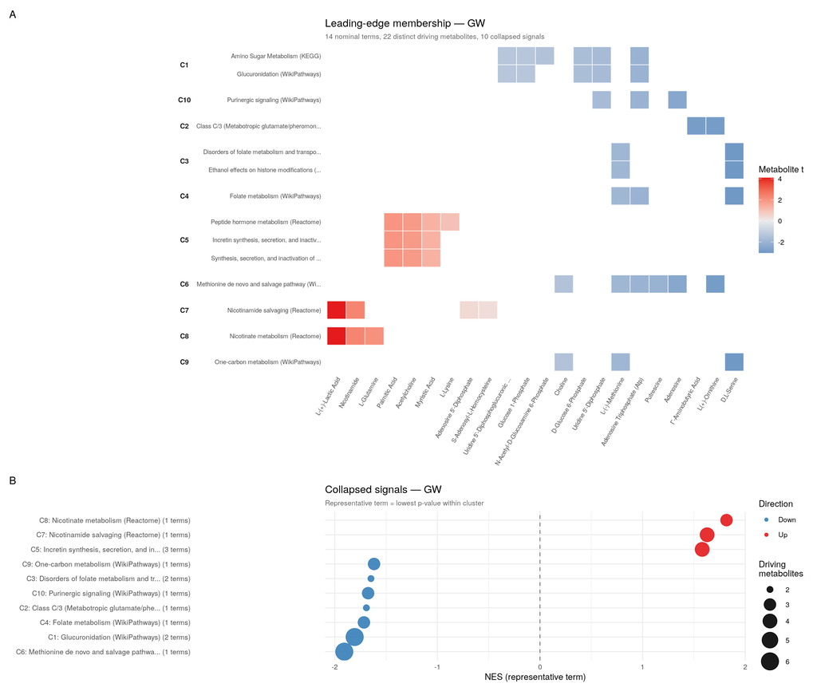

```r
if (!is.null(collapsed_gw)) {
  pA <- plot_le_matrix(collapsed_gw, "GW")
  pB <- plot_le_collapsed(collapsed_gw, "GW")

  fig_gw <- pA / pB +
    plot_layout(heights = c(2.2, 1)) +
    plot_annotation(tag_levels = "A")

  save_dual_format(fig_gw, "msea_leading_edge_collapse_gw",
                   png_path = png_path, svg_path = svg_path)
  print(fig_gw)
}
```

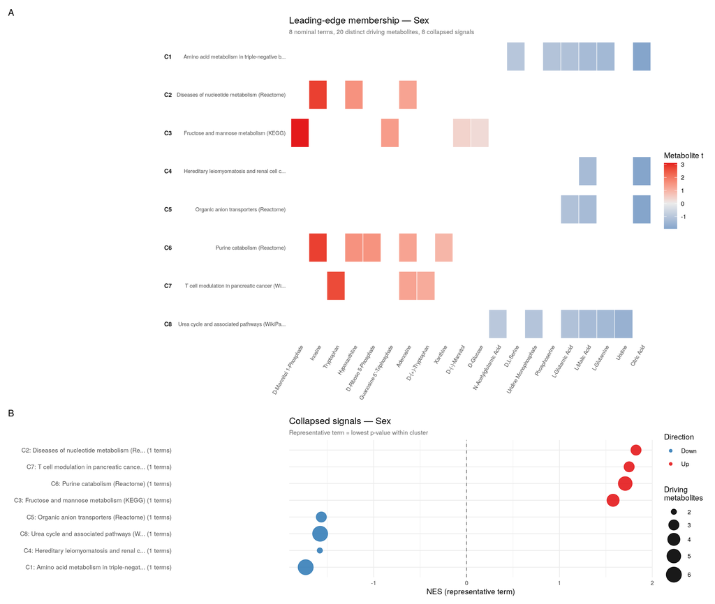

```r
if (!is.null(collapsed_sex)) {
  pA <- plot_le_matrix(collapsed_sex, "Sex")
  pB <- plot_le_collapsed(collapsed_sex, "Sex")

  fig_sex <- pA / pB +
    plot_layout(heights = c(2.2, 1)) +
    plot_annotation(tag_levels = "A")

  save_dual_format(fig_sex, "msea_leading_edge_collapse_sex",
                   png_path = png_path, svg_path = svg_path)
  print(fig_sex)
}
```

```r
for (nm in c("GW", "Sex")) {
  cl <- if (nm == "GW") collapsed_gw else collapsed_sex
  if (is.null(cl)) next
  print(
    cl$clusters %>%
      dplyr::select(cluster, representative, rep_source, n_terms,
                    NES_rep, pval_rep, padj_rep, direction,
                    mixed_direction, n_metabolites, driver_metabolites) %>%
      mutate(across(c(NES_rep), ~ round(.x, 3)),
             across(c(pval_rep, padj_rep), ~ signif(.x, 3))) %>%
      kable(caption = paste0(nm, " — collapsed leading-edge signals ",
                             "(Jaccard >= 0.7, complete linkage)")) %>%
      kable_styling(bootstrap_options = c("striped", "condensed"),
                    full_width = FALSE, font_size = 10)
  )
}
```

[output not shown]

[output cut: 218 more lines]

[output not shown]

```r
# Full untruncated names live here; the figure axes are truncated for legibility.
for (nm in c("gw", "sex")) {
  cl <- if (nm == "gw") collapsed_gw else collapsed_sex
  le <- if (nm == "gw") le_all_gw   else le_all_sex
  if (is.null(cl)) next

  write_csv(le,
            file.path(csv_path, paste0("batch2_msea_leading_edge_all_", nm, ".csv")))
  write_csv(cl$clusters,
            file.path(csv_path, paste0("batch2_msea_le_clusters_", nm, ".csv")))
  write_csv(cl$cluster_map,
            file.path(csv_path, paste0("batch2_msea_le_cluster_map_", nm, ".csv")))
}
cat("Leading-edge redundancy tables saved to:", csv_path, "\n")
```

```
## Leading-edge redundancy tables saved to: ../../results/untargeted/batch2_clean/csv
```

# Visualizations

```r
# Companion label file for truncated pathway axes.
# The dotplots clip pathway names to 45 chars; this writes the full names
# (plus plotted statistics) next to the SVG so figures stay editable.
write_pathway_labels <- function(plot_data, file_stem, label_dir, order_by) {
  if (is.null(label_dir) || is.null(file_stem)) return(invisible(NULL))
  dir.create(label_dir, recursive = TRUE, showWarnings = FALSE)

  # Degrade to unsorted rather than aborting a long render if the sort
  # column is absent (e.g. a plot function stops computing it).
  if (!is.null(order_by) && !order_by %in% names(plot_data)) {
    warning("write_pathway_labels: '", order_by,
            "' not found; writing unsorted labels for ", file_stem, ".")
    order_by <- NULL
  }

  out <- plot_data
  if (!is.null(order_by)) out <- arrange(out, desc(.data[[order_by]]))

  out <- out %>%
    mutate(plot_order = row_number()) %>%
    dplyr::select(
      plot_order,
      axis_label   = pathway_label,   # truncated string drawn on the y-axis
      pathway_full = pathway,         # untruncated, with " (Source)" suffix
      pathway_source, stars,
      dplyr::any_of(c("NES", "size", "n_hits", "set_size",
                      "odds_ratio", "pval", "padj"))
    )

  readr::write_csv(out, file.path(label_dir, paste0(file_stem, "_labels.csv")))
  invisible(out)
}

# Dot plot: NES on x, pathway on y, color = database, size = set size
# FDR significance shown as stars appended to pathway labels on the y-axis
# * p < 0.05, ** FDR < 0.05, *** FDR < 0.01
plot_msea_dotplot <- function(results, pathway_source_lookup, analysis_label,
                              top_n = 25, file_stem = NULL, label_dir = NULL) {
  if (is.null(results) || nrow(results) == 0) {
    message("No results to plot for: ", analysis_label)
    return(NULL)
  }

  plot_data <- results %>%
    left_join(pathway_source_lookup, by = c("pathway" = "pathway_label_src")) %>%
    filter(pval < 0.05) %>%
    arrange(padj) %>%
    head(top_n) %>%
    mutate(
      stars = case_when(
        padj < 0.01 ~ "**",
        padj < 0.05 ~ "*",
        TRUE ~ ""
      ),
      # Strip the " (Source)" suffix before truncating, then re-append
      # so the source is never swallowed by str_trunc
      pathway_base = str_remove(pathway,
        " \\(KEGG\\)$| \\(Reactome\\)$| \\(WikiPathways\\)$| \\(PFOCR\\)$"),
      pathway_short = str_trunc(pathway_base, 45),
      pathway_label = paste0(
        pathway_short, " (", pathway_source, ")",
        if_else(stars != "", paste0(" ", stars), "")
      )
    )

  if (nrow(plot_data) == 0) {
    message("No nominally significant pathways for: ", analysis_label)
    return(NULL)
  }

  write_pathway_labels(plot_data, file_stem, label_dir, order_by = "NES")

  ggplot(
    plot_data,
    aes(
      x = NES,
      y = reorder(pathway_label, NES),
      color = pathway_source,
      size = size,
      shape = pathway_source
    )
  ) +
    geom_point(alpha = 0.85) +
    geom_vline(xintercept = 0, linetype = "dashed", color = "grey50") +
    scale_color_manual(
      name = "Database",
      values = c(
        "KEGG"         = "#E41A1C",
        "Reactome"     = "#377EB8",
        "WikiPathways" = "#4DAF4A",
        "PFOCR"        = "#FF7F00"
      )
    ) +
    scale_shape_manual(
      name = "Database",
      values = c(
        "KEGG"         = 16,
        "Reactome"     = 17,
        "WikiPathways" = 15,
        "PFOCR"        = 18
      )
    ) +
    scale_size_continuous(name = "Set size", range = c(2, 8)) +
    theme_minimal(base_size = 11) +
    labs(
      x = "Normalized Enrichment Score (NES)",
      y = NULL,
      title = paste0("MSEA — ", analysis_label),
      subtitle = paste0(
        "Top ", nrow(plot_data), " pathways by FDR (p < 0.05 shown)\n",
        "* FDR < 0.05   ** FDR < 0.01"
      )
    ) +
    theme(
      plot.title = element_text(hjust = 0.5),
      plot.subtitle = element_text(hjust = 0.5, color = "grey40", size = 9),
      axis.text.y = element_text(size = 8),
      legend.position = "right"
    )
}
```

## GW Dot Plot

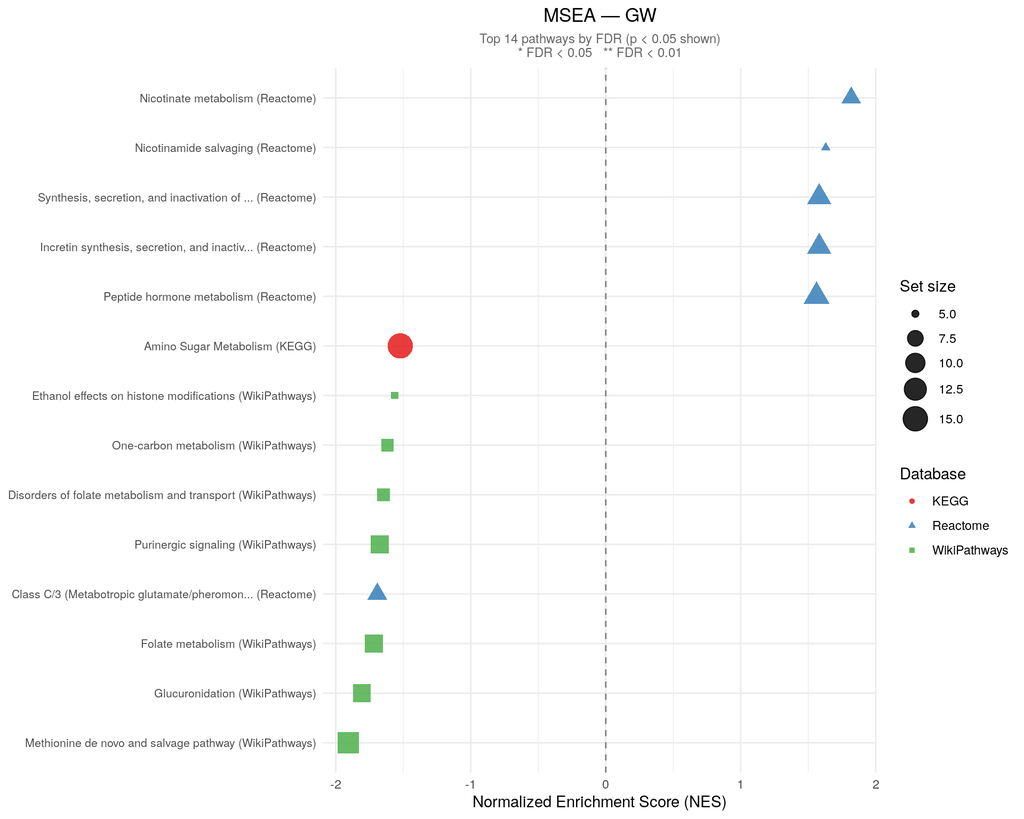

```r
p_gw  <- plot_msea_dotplot(msea_gw,  pathway_source_lookup, "GW",
                           file_stem = "msea_gw_dotplot",  label_dir = svg_path)
if (!is.null(p_gw)) {
  save_dual_format(p_gw, "msea_gw_dotplot", png_path = png_path, svg_path = svg_path)
  print(p_gw)
}
```

## Sex Dot Plot

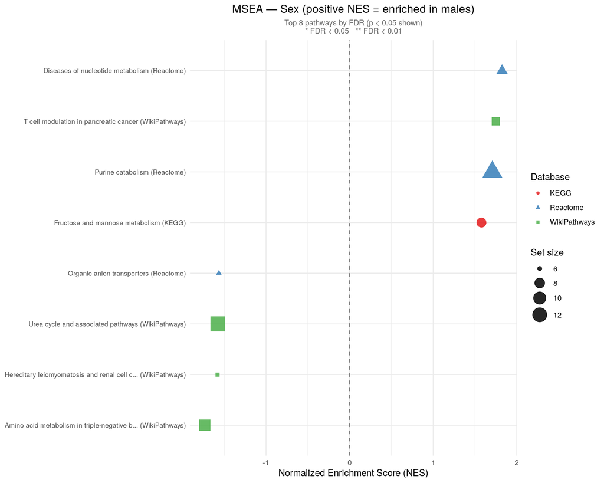

```r
p_sex <- plot_msea_dotplot(msea_sex, pathway_source_lookup,
                           "Sex (positive NES = enriched in males)",
                           file_stem = "msea_sex_dotplot", label_dir = svg_path)
if (!is.null(p_sex)) {
  save_dual_format(p_sex, "msea_sex_dotplot", png_path = png_path, svg_path = svg_path)
  print(p_sex)
}
```

## fgsea Enrichment Plots — Top GW Pathways

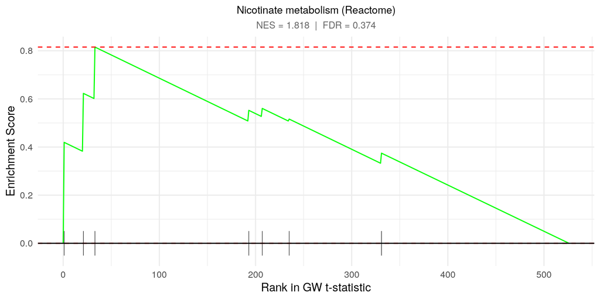

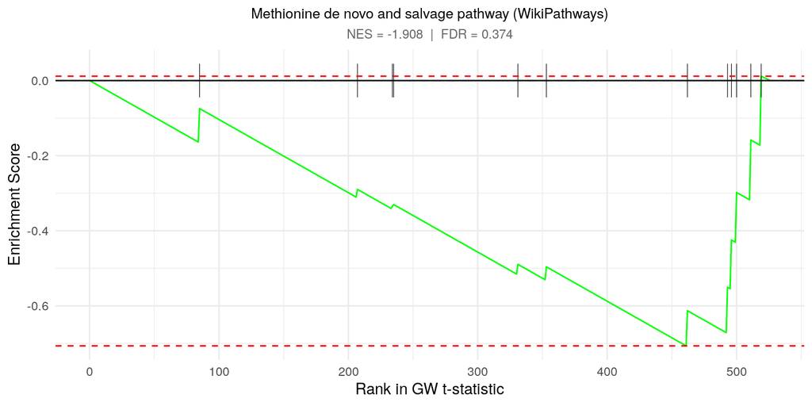

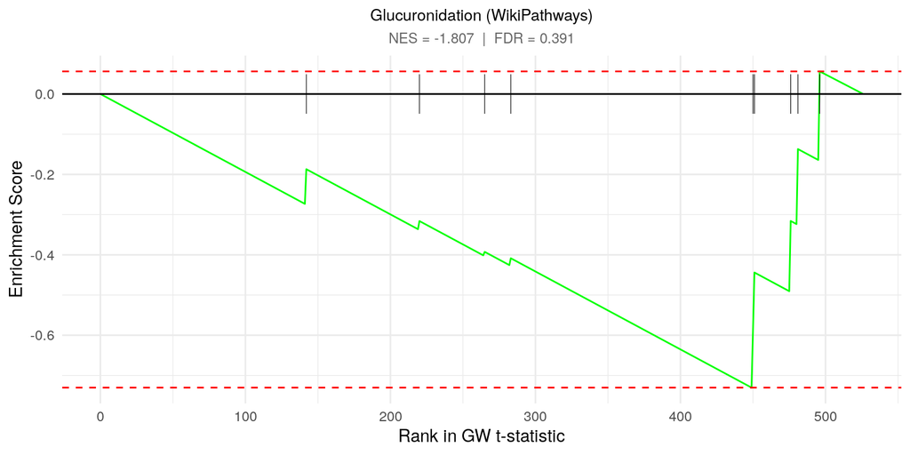

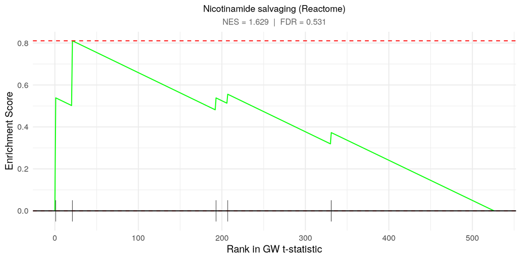

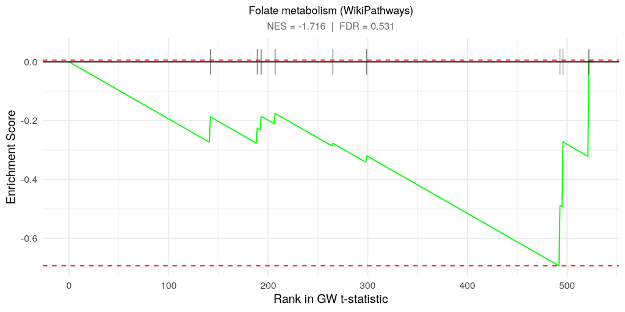

```r
# Individual enrichment plots for top 5 GW pathways by FDR
if (!is.null(msea_gw) && nrow(msea_gw) > 0) {
  ranked_gw <- gw_limma %>%
    filter(!is.na(t)) %>%
    arrange(desc(t)) %>%
    dplyr::select(Name, t) %>%
    deframe()

  # Restrict to pathways present in filtered list
  pathway_list_gw <- lapply(pathway_list, function(x) intersect(x, names(ranked_gw)))
  pathway_list_gw <- pathway_list_gw[lengths(pathway_list_gw) >= 5]

  top_gw_pathways <- msea_gw %>%
    arrange(padj) %>%
    head(5) %>%
    pull(pathway)

  for (pw in top_gw_pathways) {
    if (pw %in% names(pathway_list_gw)) {
      p <- plotEnrichment(pathway_list_gw[[pw]], ranked_gw) +
        labs(
          title = str_trunc(pw, 70),
          subtitle = paste0(
            "NES = ", round(msea_gw$NES[msea_gw$pathway == pw], 3),
            "  |  FDR = ", signif(msea_gw$padj[msea_gw$pathway == pw], 3)
          ),
          x = "Rank in GW t-statistic",
          y = "Enrichment Score"
        ) +
        theme_minimal() +
        theme(
          plot.title = element_text(size = 10, hjust = 0.5),
          plot.subtitle = element_text(size = 9, hjust = 0.5, color = "grey40")
        )
      print(p)
    }
  }
}
```

## fgsea Enrichment Plots — Top Sex Pathways

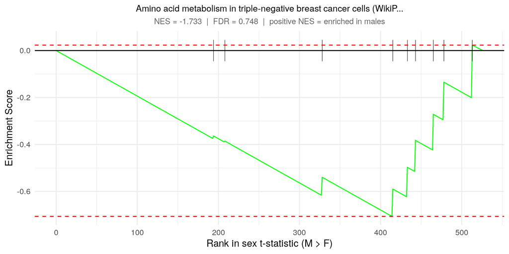

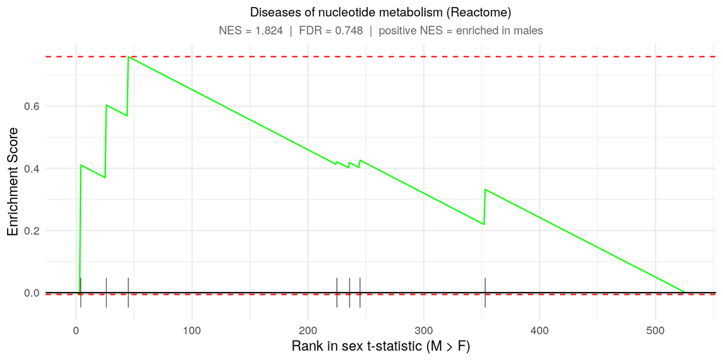

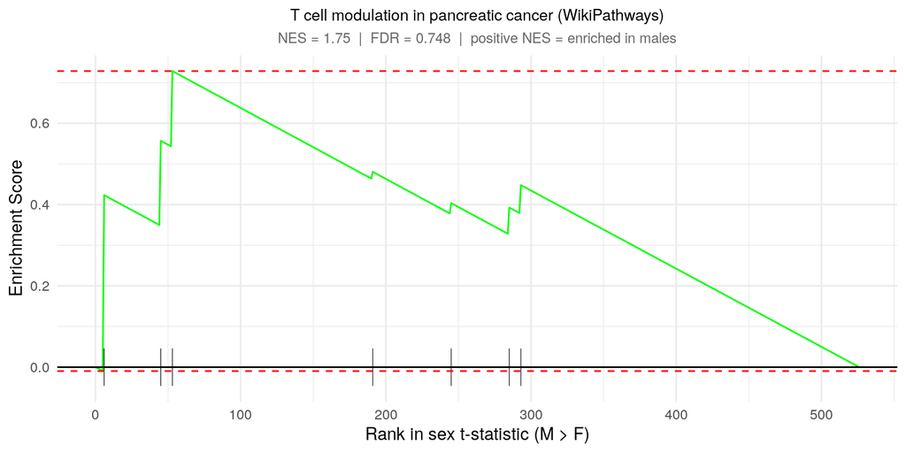

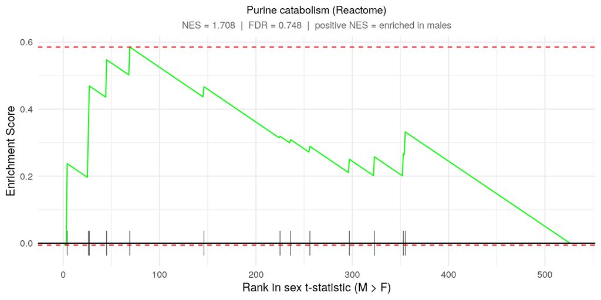

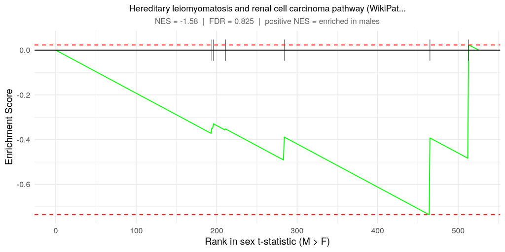

```r
if (!is.null(msea_sex) && nrow(msea_sex) > 0) {
  ranked_sex <- sex_limma %>%
    filter(!is.na(t)) %>%
    arrange(desc(t)) %>%
    dplyr::select(Name, t) %>%
    deframe()

  pathway_list_sex <- lapply(pathway_list, function(x) intersect(x, names(ranked_sex)))
  pathway_list_sex <- pathway_list_sex[lengths(pathway_list_sex) >= 5]

  top_sex_pathways <- msea_sex %>%
    arrange(padj) %>%
    head(5) %>%
    pull(pathway)

  for (pw in top_sex_pathways) {
    if (pw %in% names(pathway_list_sex)) {
      p <- plotEnrichment(pathway_list_sex[[pw]], ranked_sex) +
        labs(
          title = str_trunc(pw, 70),
          subtitle = paste0(
            "NES = ", round(msea_sex$NES[msea_sex$pathway == pw], 3),
            "  |  FDR = ", signif(msea_sex$padj[msea_sex$pathway == pw], 3),
            "  |  positive NES = enriched in males"
          ),
          x = "Rank in sex t-statistic (M > F)",
          y = "Enrichment Score"
        ) +
        theme_minimal() +
        theme(
          plot.title = element_text(size = 10, hjust = 0.5),
          plot.subtitle = element_text(size = 9, hjust = 0.5, color = "grey40")
        )
      print(p)
    }
  }
}
```

# Over-Representation Analysis (ORA)

ORA tests whether a specific hit list is enriched for particular pathways compared to the full measured background, using Fisher’s exact test. Unlike MSEA, ORA uses a binary foreground/background split and is sensitive to the threshold chosen. Results should be interpreted alongside the MSEA above.

The background for all ORA tests is the full set of measured metabolites.

```r
# Fisher's exact test ORA
# foreground: character vector of hit metabolite Names
# background: character vector of all measured metabolite Names
# pathway_list: named list of pathway member vectors (built above)
# pathway_source_lookup: data frame mapping pathway_label_src -> pathway_source
run_ora <- function(foreground, background, pathway_list,
                    pathway_source_lookup, analysis_label) {

  cat("\n===", analysis_label, "===\n")
  cat("Foreground:", length(foreground), "metabolites\n")
  cat("Background:", length(background), "metabolites\n")

  if (length(foreground) == 0) {
    cat("Empty foreground — skipping.\n")
    return(NULL)
  }

  bg_only <- background[!background %in% foreground]

  results <- map_dfr(names(pathway_list), function(pw) {
    members <- pathway_list[[pw]]

    a <- sum(foreground %in% members)   # fg in pathway
    b <- length(foreground) - a         # fg not in pathway
    c <- sum(bg_only %in% members)      # bg in pathway
    d <- length(bg_only) - c            # bg not in pathway

    ft <- fisher.test(matrix(c(a, b, c, d), nrow = 2), alternative = "greater")

    tibble(
      pathway    = pw,
      n_hits     = a,
      set_size   = a + c,
      odds_ratio = as.numeric(ft$estimate),
      pval       = ft$p.value,
      hit_names  = paste(foreground[foreground %in% members], collapse = ";")
    )
  }) %>%
    filter(n_hits > 0) %>%
    mutate(padj = p.adjust(pval, method = "BH")) %>%
    left_join(pathway_source_lookup, by = c("pathway" = "pathway_label_src")) %>%
    arrange(padj, pval)

  cat("Pathways with \u22651 hit:", nrow(results), "\n")
  cat("Nominal p < 0.05:         ", sum(results$pval  < 0.05, na.rm = TRUE), "\n")
  cat("FDR < 0.05:               ", sum(results$padj < 0.05, na.rm = TRUE), "\n")

  results
}

# Display helper — top N by p-value, formatted kable
display_ora_table <- function(results, caption, top_n = 20) {
  if (is.null(results) || nrow(results) == 0) {
    cat("No results.\n"); return(invisible(NULL))
  }
  results %>%
    head(top_n) %>%
    mutate(
      odds_ratio = round(odds_ratio, 2),
      pval       = signif(pval, 3),
      padj       = signif(padj, 3),
      hit_names  = str_trunc(hit_names, 60)
    ) %>%
    dplyr::select(pathway, pathway_source, n_hits, set_size,
                  odds_ratio, pval, padj, hit_names) %>%
    rename(
      Pathway           = pathway,
      Source            = pathway_source,
      `Hits in set`     = n_hits,
      `Set size`        = set_size,
      `Odds ratio`      = odds_ratio,
      `p-value`         = pval,
      `FDR`             = padj,
      `Hit metabolites` = hit_names
    ) %>%
    kable(caption = caption) %>%
    kable_styling(bootstrap_options = c("striped", "condensed"),
                  full_width = FALSE, font_size = 11) %>%
    print()
}

# ORA dot plot — mirrors MSEA plot style
plot_ora_dotplot <- function(results, analysis_label, top_n = 20,
                             file_stem = NULL, label_dir = NULL) {
  if (is.null(results) || nrow(results) == 0) return(NULL)

  plot_data <- results %>%
    filter(pval < 0.05) %>%
    head(top_n) %>%
    mutate(
      stars = case_when(
        padj < 0.01 ~ "**",
        padj < 0.05 ~ "*",
        TRUE        ~ ""
      ),
      log2_or = log2(odds_ratio),
      pathway_base  = str_remove(pathway,
        " \\(KEGG\\)$| \\(Reactome\\)$| \\(WikiPathways\\)$| \\(PFOCR\\)$"),
      pathway_short = str_trunc(pathway_base, 45),
      pathway_label = paste0(pathway_short, " (", pathway_source, ")",
                             if_else(stars != "", paste0(" ", stars), ""))
    )

  if (nrow(plot_data) == 0) {
    message("No nominally significant pathways for: ", analysis_label)
    return(NULL)
  }

  write_pathway_labels(plot_data, file_stem, label_dir, order_by = "log2_or")

  ggplot(plot_data,
         aes(x = log2(odds_ratio),
             y = reorder(pathway_label, log2(odds_ratio)),
             color = pathway_source,
             shape = pathway_source,
             size  = set_size)) +
    geom_point(alpha = 0.85) +
    geom_vline(xintercept = 0, linetype = "dashed", color = "grey50") +
    scale_color_manual(name = "Database",
                       values = c(
                         "KEGG"         = "#E41A1C",
                         "Reactome"     = "#377EB8",
                         "WikiPathways" = "#4DAF4A",
                         "PFOCR"        = "#FF7F00"
                       )) +
    scale_shape_manual(name = "Database",
                       values = c(
                         "KEGG"         = 16,
                         "Reactome"     = 17,
                         "WikiPathways" = 15,
                         "PFOCR"        = 18
                       )) +
    scale_size_continuous(name = "Set size", range = c(2, 8)) +
    theme_minimal(base_size = 11) +
    labs(
      x        = "log2(Odds Ratio)",
      y        = NULL,
      title    = paste0("ORA — ", analysis_label),
      subtitle = paste0("Top ", nrow(plot_data), " pathways by p-value (p < 0.05 shown)\n",
                        "* FDR < 0.05   ** FDR < 0.01")
    ) +
    theme(
      plot.title    = element_text(hjust = 0.5),
      plot.subtitle = element_text(hjust = 0.5, color = "grey40", size = 9),
      axis.text.y   = element_text(size = 8),
      legend.position = "right"
    )
}

# Background: all measured metabolite Names
background_all <- gw_limma$Name
```

## Load Hit Lists

```r
# Sex limma — nominally significant
sex_hits_nominal <- sex_limma %>%
  filter(P.Value < 0.05) %>%
  pull(Name)
cat("Sex limma nominal (p < 0.05):      ", length(sex_hits_nominal), "\n")
```

```
## Sex limma nominal (p < 0.05):       19
```

```r
# GW limma — nominally significant
gw_hits_nominal <- gw_limma %>%
  filter(P.Value < 0.05) %>%
  pull(Name)
cat("GW limma nominal (p < 0.05):       ", length(gw_hits_nominal), "\n")
```

```
## GW limma nominal (p < 0.05):        59
```

```r
# GW limma — FDR significant
gw_hits_fdr <- gw_limma %>%
  filter(adj.P.Val < 0.05) %>%
  pull(Name)
cat("GW limma FDR (adj.P.Val < 0.05):   ", length(gw_hits_fdr), "\n")
```

```
## GW limma FDR (adj.P.Val < 0.05):    2
```

```r
# Sex PLS-DA VIP
plsda_vip <- read_csv(file.path(csv_path, "batch2_sex_plsda_vip.csv"),
                      show_col_types = FALSE)
sex_hits_vip1 <- plsda_vip %>% filter(VIP_comp1 > 1) %>% pull(Name)
sex_hits_vip2 <- plsda_vip %>% filter(VIP_comp1 > 2) %>% pull(Name)
cat("Sex PLS-DA VIP > 1:                ", length(sex_hits_vip1), "\n")
```

```
## Sex PLS-DA VIP > 1:                 205
```

```r
cat("Sex PLS-DA VIP > 2:                ", length(sex_hits_vip2), "\n")
```

```
## Sex PLS-DA VIP > 2:                 9
```

## Run ORA

```r
ora_sex_nominal <- run_ora(sex_hits_nominal, background_all, pathway_list,
                           pathway_source_lookup, "Sex limma nominal (p < 0.05)")
```

```
##
## === Sex limma nominal (p < 0.05) ===
## Foreground: 19 metabolites
## Background: 525 metabolites
## Pathways with ≥1 hit: 36
## Nominal p < 0.05:          1
## FDR < 0.05:                0
```

```r
ora_gw_nominal  <- run_ora(gw_hits_nominal,  background_all, pathway_list,
                           pathway_source_lookup, "GW limma nominal (p < 0.05)")
```

```
##
## === GW limma nominal (p < 0.05) ===
## Foreground: 59 metabolites
## Background: 525 metabolites
## Pathways with ≥1 hit: 125
## Nominal p < 0.05:          2
## FDR < 0.05:                0
```

```r
ora_gw_fdr      <- run_ora(gw_hits_fdr,      background_all, pathway_list,
                           pathway_source_lookup, "GW limma FDR (adj.P < 0.05)")
```

```
##
## === GW limma FDR (adj.P < 0.05) ===
## Foreground: 2 metabolites
## Background: 525 metabolites
## Pathways with ≥1 hit: 0
## Nominal p < 0.05:          0
## FDR < 0.05:                0
```

```r
ora_vip1        <- run_ora(sex_hits_vip1,    background_all, pathway_list,
                           pathway_source_lookup, "Sex PLS-DA VIP > 1")
```

```
##
## === Sex PLS-DA VIP > 1 ===
## Foreground: 205 metabolites
## Background: 525 metabolites
## Pathways with ≥1 hit: 182
## Nominal p < 0.05:          1
## FDR < 0.05:                0
```

```r
ora_vip2        <- run_ora(sex_hits_vip2,    background_all, pathway_list,
                           pathway_source_lookup, "Sex PLS-DA VIP > 2")
```

```
##
## === Sex PLS-DA VIP > 2 ===
## Foreground: 9 metabolites
## Background: 525 metabolites
## Pathways with ≥1 hit: 34
## Nominal p < 0.05:          0
## FDR < 0.05:                0
```

## Results

### Sex — Limma Nominal

```r
display_ora_table(ora_sex_nominal,
                  "ORA: Sex limma nominal (p < 0.05) — top 20 by p-value")
```

[output not shown]

[output cut: 163 more lines]

[output not shown]

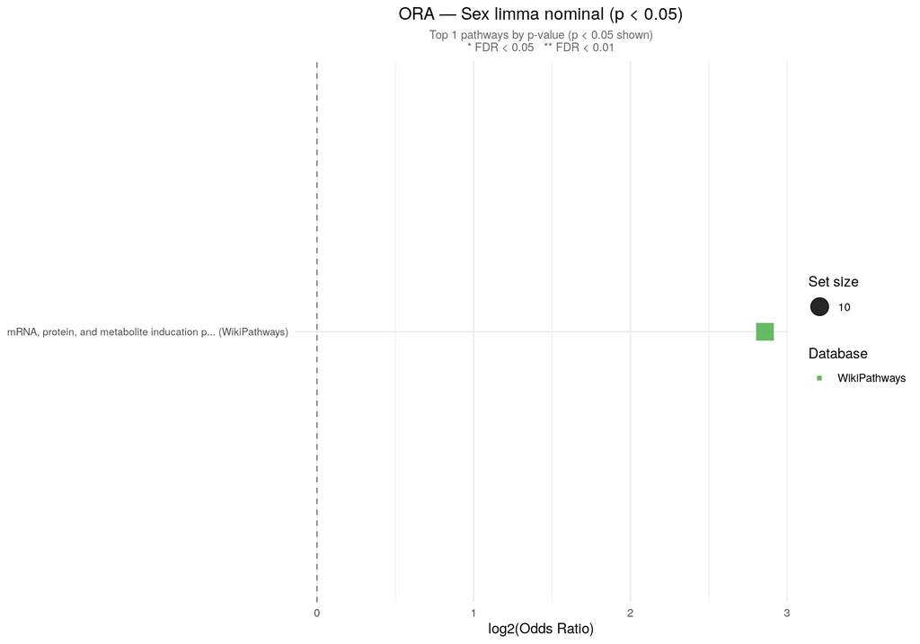

```r
p <- plot_ora_dotplot(ora_sex_nominal, "Sex limma nominal (p < 0.05)",
                      file_stem = "ora_sex_limma_nominal", label_dir = svg_path)
if (!is.null(p)) {
  save_dual_format(p, "ora_sex_limma_nominal",
                   png_path = png_path, svg_path = svg_path)
  print(p)
}
```

### GW — Limma Nominal

```r
display_ora_table(ora_gw_nominal,
                  "ORA: GW limma nominal (p < 0.05) — top 20 by p-value")
```

[output not shown]

[output cut: 163 more lines]

[output not shown]

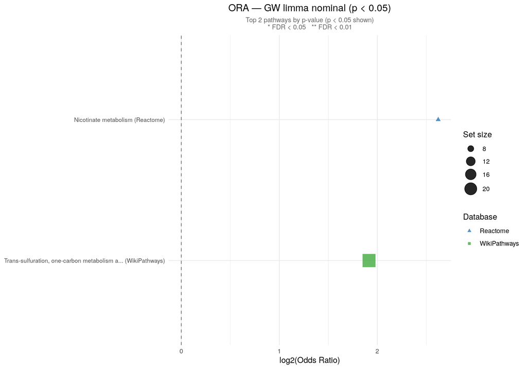

```r
p <- plot_ora_dotplot(ora_gw_nominal,  "GW limma nominal (p < 0.05)",
                      file_stem = "ora_gw_limma_nominal",  label_dir = svg_path)
if (!is.null(p)) {
  save_dual_format(p, "ora_gw_limma_nominal",
                   png_path = png_path, svg_path = svg_path)
  print(p)
}
```

### GW — Limma FDR

```r
display_ora_table(ora_gw_fdr,
                  "ORA: GW limma FDR (adj.P < 0.05) — top 20 by p-value")
```

```
## No results.
```

```r
p <- plot_ora_dotplot(ora_gw_fdr,      "GW limma FDR (adj.P < 0.05)",
                      file_stem = "ora_gw_limma_fdr",      label_dir = svg_path)
if (!is.null(p)) {
  save_dual_format(p, "ora_gw_limma_fdr",
                   png_path = png_path, svg_path = svg_path)
  print(p)
}
```

### Sex — PLS-DA VIP > 1

```r
display_ora_table(ora_vip1,
                  "ORA: Sex PLS-DA VIP > 1 — top 20 by p-value")
```

[output not shown]

[output cut: 162 more lines]

[output not shown]

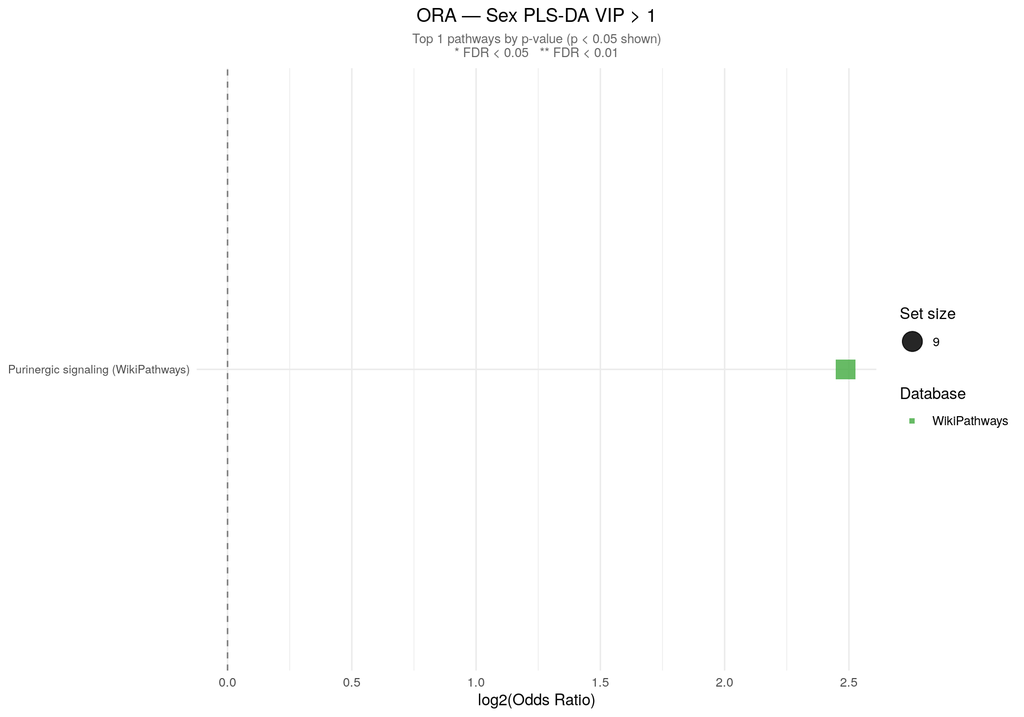

```r
p <- plot_ora_dotplot(ora_vip1,        "Sex PLS-DA VIP > 1",
                      file_stem = "ora_sex_plsda_vip1",    label_dir = svg_path)
if (!is.null(p)) {
  save_dual_format(p, "ora_sex_plsda_vip1",
                   png_path = png_path, svg_path = svg_path)
  print(p)
}
```

### Sex — PLS-DA VIP > 2

```r
display_ora_table(ora_vip2,
                  "ORA: Sex PLS-DA VIP > 2 — top 20 by p-value")
```

[output not shown]

[output cut: 162 more lines]

[output not shown]

```r
p <- plot_ora_dotplot(ora_vip2,        "Sex PLS-DA VIP > 2",
                      file_stem = "ora_sex_plsda_vip2",    label_dir = svg_path)
if (!is.null(p)) {
  save_dual_format(p, "ora_sex_plsda_vip2",
                   png_path = png_path, svg_path = svg_path)
  print(p)
}
```

## Save ORA Results

```r
ora_list <- list(
  sex_limma_nominal = ora_sex_nominal,
  gw_limma_nominal  = ora_gw_nominal,
  gw_limma_fdr      = ora_gw_fdr,
  sex_plsda_vip1    = ora_vip1,
  sex_plsda_vip2    = ora_vip2
)

for (nm in names(ora_list)) {
  df <- ora_list[[nm]]
  if (!is.null(df)) {
    write_csv(df, file.path(csv_path, paste0("batch2_ora_", nm, ".csv")))
  }
}
cat("ORA results saved to:", csv_path, "\n")
```

```
## ORA results saved to: ../../results/untargeted/batch2_clean/csv
```

# Save Results

```r
# Save pathway sets (for reproducibility / supplementary)
pathway_sets_out <- pathway_sets_raw %>%
  distinct(Name, pathway_id, pathway_label) %>%
  left_join(pathway_info %>% dplyr::select(pathway_id, pathway_source),
    by = "pathway_id"
  )
write_csv(
  pathway_sets_out,
  file.path(csv_path, "batch2_pathway_metabolite_mapping.csv")
)

# Save MSEA results
if (!is.null(msea_gw)) {
  msea_gw_out <- msea_gw %>%
    left_join(pathway_source_lookup, by = c("pathway" = "pathway_label_src")) %>%
    mutate(leadingEdge = map_chr(leadingEdge, ~ paste(.x, collapse = ";")))
  write_csv(msea_gw_out, file.path(csv_path, "batch2_msea_gw.csv"))
}

if (!is.null(msea_sex)) {
  msea_sex_out <- msea_sex %>%
    left_join(pathway_source_lookup, by = c("pathway" = "pathway_label_src")) %>%
    mutate(leadingEdge = map_chr(leadingEdge, ~ paste(.x, collapse = ";")))
  write_csv(msea_sex_out, file.path(csv_path, "batch2_msea_sex.csv"))
}

cat("Files saved to:", csv_path, "\n")
```

```
## Files saved to: ../../results/untargeted/batch2_clean/csv
```